# Meta-analysis using dmrff

## Download and prepare DNA methylation datasets

We’ll use a couple of small cord blood DNA methylation datasets available on GEO: GSE79056, GSE62924.

*Loading each dataset takes about 1 minute.*

```r
accessions <- c("GSE79056", "GSE62924")
library(geograbi) ## https://github.com/yousefi138
samples <- sapply(accessions, geograbi.get.samples, simplify=F)
```

```
## Tue Dec 12 19:02:41 2023 reading
## Tue Dec 12 19:02:42 2023 reading
```

```r
vars <- sapply(samples, geograbi.extract.characteristics, simplify=F)
system.time(methylation <- sapply(accessions, geograbi.get.data, simplify=F))
```

```
## Tue Dec 12 19:02:44 2023 reading
## Tue Dec 12 19:02:53 2023 reading
```

```
##    user  system elapsed
##  15.290   1.666  15.312
```

Remove non-CpG probes from the datasets.

```r
for (acc in accessions)
    methylation[[acc]] <- methylation[[acc]][grepl("^c", rownames(methylation[[acc]])),]
```

Extract the variable of interest from each dataset.

```r
variable <- sapply(accessions, function(acc) {
    idx <- grep("(ga weeks|gestational_age|gestational age)", colnames(vars[[acc]]))
    stopifnot(length(idx) == 1)
    as.numeric(vars[[acc]][,idx])
}, simplify=F)
```

Remove samples with incomplete data.

```r
for (acc in accessions) {
    idx <- which(!is.na(variable[[acc]]))
    samples[[acc]] <- samples[[acc]][idx,]
    vars[[acc]] <- vars[[acc]][idx,]
    variable[[acc]] <- variable[[acc]][idx]
    methylation[[acc]] <- methylation[[acc]][,idx]
}
```

## Calculate surrogate variables to handle unknown confounding

*SVA takes a few seconds for each dataset.*

```r
library(sva, quietly=T)
set.seed(20191029)
covariates <- sapply(accessions, function(acc) {
    mod <- model.matrix(~ var, data.frame(var=variable[[acc]]))
    mod0 <- mod[,1,drop=F]
    random.idx <- sample(1:nrow(methylation[[acc]]), 5000)
    meth.sva <- methylation[[acc]][random.idx,]
    meth.mean <- rowMeans(meth.sva, na.rm=T)
    idx <- which(is.na(meth.sva), arr.ind=T)
    if (nrow(idx) > 0)
        meth.sva[idx] <- meth.mean[idx[,1]]
    sva(meth.sva, mod=mod, mod0=mod0)$sv
}, simplify=F)
```

```
## Number of significant surrogate variables is:  3
## Iteration (out of 5 ):1  2  3  4  5  Number of significant surrogate variables is:  2
## Iteration (out of 5 ):1  2  3  4  5
```

## Test the associations with gestational age

*Testing associations takes a few seconds for each dataset.*

```r
library(limma)
stats <- sapply(accessions, function(acc) {
    mod <- model.matrix(~ ., data.frame(ga=variable[[acc]],
                                        covariates[[acc]]))
    fit <- lmFit(methylation[[acc]], mod)
    fit <- eBayes(fit)
    data.frame(estimate=fit$coefficients[,"ga"],
               se=sqrt(fit$s2.post) * fit$stdev.unscaled[,"ga"],
               p.value=fit$p.value[,"ga"])
},simplify=F)
```

Now we check the agreement between the datasets.

```r
kable(sapply(stats, function(a) sapply(stats, function(b) {
    sites <- intersect(rownames(a), rownames(b))
    sites <- sites[order(a[sites,"p.value"])[1:100]]
    cor(a[sites,"estimate"], b[sites,"estimate"])
})))
```

|  | GSE79056 | GSE62924 |
| --- | --- | --- |
| GSE79056 | 1.0000000 | 0.5844022 |
| GSE62924 | 0.8681764 | 1.0000000 |

A previous study reported thousands of associations with gestational age:

> Bohlin J, et al. Prediction of gestational age based on genome-wide differentially methylated regions. Genome Biol. 2016;17(1):207.

The effect estimates are strongly associated.

```r
bohlin <- read.csv("bohlin.csv",stringsAsFactors=F,row.names=1)
kable(sapply(stats, function(stats) {
    cor(bohlin$estimate, stats[rownames(bohlin),"estimate"], use="p")
}))
```

|  | x |
| --- | --- |
| GSE79056 | 0.7631472 |
| GSE62924 | 0.5647381 |

## Annotate summary statistics with genomic locations

If your data was generated using one of the Illumina BeadChips, then it is possible to annotate your EWAS summary statistics using the appropriate [Bioconductor](https://www.bioconductor.org/) annotation package.

For the Illumina 450K microaray, we use the `IlluminaHumanMethylation450kanno.ilmn12.hg19` package.

```r
if (!require(IlluminaHumanMethylation450kanno.ilmn12.hg19, quietly=T)) {
    install.packages("BiocManager")
    BiocManager::install("IlluminaHumanMethylation450kanno.ilmn12.hg19")
}
```

```
## locfit 1.5-9.6 	 2022-07-11
```

```
## Setting options('download.file.method.GEOquery'='auto')
```

```
## Setting options('GEOquery.inmemory.gpl'=FALSE)
```

```r
library(IlluminaHumanMethylation450kanno.ilmn12.hg19)
```

If we were using the more recent Illumina MethylationEPIC BeadChip, then we would load the `IlluminaHumanMethylationEPICanno.ilm10b2.hg19` package instead.

We construct an annotation data frame as follows:

```r
data(list="IlluminaHumanMethylation450kanno.ilmn12.hg19")
data(Locations)
data(Other)
annotation <- cbind(as.data.frame(Locations), as.data.frame(Other))
```

We then add the annotation to the `stats` object (**Warning**: we assume that the row names of the `stats` object are the Illumina CpG site identifiers, e.g. cg05775921).

```r
stats <- sapply(stats, function(stats) {
    annotation <- annotation[match(rownames(stats), rownames(annotation)),]
    cbind(stats, annotation)
}, simplify=F)
```

## Construct ‘pre’ objects for DMR meta-analysis

*Takes about 2 minutes per dataset to calculate CpG site correlations.*

```r
library(dmrff)
pre <- sapply(accessions, function(acc) {
    cat(date(), "pre", acc, "\n")
    with(stats[[acc]], dmrff.pre(estimate, se, methylation[[acc]], chr, pos))
}, simplify=F)
```

```
## Tue Dec 12 19:04:18 2023 pre GSE79056
## Tue Dec 12 19:05:22 2023 pre GSE62924
```

## Perform DMR meta-analysis

```r
options(mc.cores=20) ## if you have 20 processors available
meta <- dmrff.meta(pre)
```

```
## [dmrff.candidates] Tue Dec 12 19:06:45 2023 Found  92222  candidate regions.
```

The output contains a data frame of the meta-analysed regions and the EWAS meta-analysis on which it was based.

```r
kable(meta$dmrs[1:2,])
```

| chr | start | end | n | B | S | estimate | se | z | p.value | p.adjust |
| --- | --- | --- | --- | --- | --- | --- | --- | --- | --- | --- |
| chr6 | 32120203 | 32121113 | 18 | NA | NA | 0.1363391 | 0.0104200 | 13.084374 | 0e+00 | 0.0000000 |
| chr6 | 32119874 | 32119874 | 1 | NA | NA | 0.1136654 | 0.0209026 | 5.437861 | 1e-07 | 0.0368855 |

```r
kable(meta$ewas[1:2,])
```

|  | estimate | se | z | p.value | chr | pos |
| --- | --- | --- | --- | --- | --- | --- |
| cg13869341 | 0.0196382 | 0.0270016 | 0.7272998 | 0.4670423 | chr1 | 15865 |
| cg14008030 | -0.0030598 | 0.0201270 | -0.1520225 | 0.8791692 | chr1 | 18827 |

Here we add the CpG sites and gene names to the EWAS sites:

```r
idx <- match(with(meta$ewas, paste(chr,pos)),
             with(annotation, paste(chr,pos)))
meta$ewas$cpg <- rownames(annotation)[idx]
meta$ewas$gene <- annotation$UCSC_RefGene_Name[idx]
```

## Meta-analyzed DMRs

```r
dmrs <- meta$dmrs[which(meta$dmrs$p.adjust < 0.05 & meta$dmrs$n >= 2), ]
```

We’ve identified 1987 DMRs with Bonferroni adjusted p < 0.05.

For convenience, we’ll just look at DMRs on chromosome 6 with at least 5 CpG sites.

```r
dmrs6 <- meta$dmrs[which(meta$dmrs$p.adjust < 0.05
                         & meta$dmrs$n >= 5
                         & meta$dmrs$chr == "chr6"), ]
dmrs6 <- dmrs6[order(dmrs6$start),]
kable(dmrs6[,c("chr","start","end","n","estimate","se","p.value","p.adjust")])
```

|  | chr | start | end | n | estimate | se | p.value | p.adjust |
| --- | --- | --- | --- | --- | --- | --- | --- | --- |
| 3259 | chr6 | 1635611 | 1635847 | 5 | 0.1027082 | 0.0078696 | 0e+00 | 0.0000000 |
| 1218 | chr6 | 15504844 | 15506085 | 9 | -0.1462422 | 0.0121251 | 0e+00 | 0.0000000 |
| 2159 | chr6 | 25652383 | 25652602 | 7 | 0.0880595 | 0.0162855 | 1e-07 | 0.0437835 |
| 5135 | chr6 | 28543262 | 28543670 | 5 | 0.0989848 | 0.0152585 | 0e+00 | 0.0000598 |
| 3266 | chr6 | 29520752 | 29521046 | 6 | 0.1262316 | 0.0185271 | 0e+00 | 0.0000065 |
| 2164 | chr6 | 29571363 | 29571693 | 8 | 0.0801718 | 0.0070362 | 0e+00 | 0.0000000 |
| 3272 | chr6 | 29576987 | 29577348 | 5 | 0.0433758 | 0.0042732 | 0e+00 | 0.0000000 |
| 8281 | chr6 | 29577916 | 29578423 | 5 | 0.0311143 | 0.0056372 | 0e+00 | 0.0232597 |
| 643 | chr6 | 29589573 | 29589729 | 5 | 0.0352142 | 0.0060229 | 0e+00 | 0.0034298 |
| 88 | chr6 | 29599012 | 29599836 | 10 | 0.1287574 | 0.0118910 | 0e+00 | 0.0000000 |
| 1219 | chr6 | 29911295 | 29911550 | 7 | -0.1202450 | 0.0151196 | 0e+00 | 0.0000000 |
| 264 | chr6 | 30127760 | 30128775 | 15 | 0.0328547 | 0.0031879 | 0e+00 | 0.0000000 |
| 66 | chr6 | 30458158 | 30459317 | 12 | -0.1553172 | 0.0110948 | 0e+00 | 0.0000000 |
| 67 | chr6 | 30459540 | 30460600 | 9 | -0.1038827 | 0.0125606 | 0e+00 | 0.0000000 |
| 3918 | chr6 | 30581820 | 30582416 | 6 | -0.1515777 | 0.0125543 | 0e+00 | 0.0000000 |
| 221 | chr6 | 30652771 | 30653530 | 9 | -0.1228585 | 0.0147872 | 0e+00 | 0.0000000 |
| 2221 | chr6 | 30850543 | 30850977 | 8 | 0.0708181 | 0.0120973 | 0e+00 | 0.0032814 |
| 238 | chr6 | 30854161 | 30854551 | 5 | 0.1272353 | 0.0190420 | 0e+00 | 0.0000161 |
| 3299 | chr6 | 30955992 | 30956440 | 5 | 0.0511286 | 0.0066766 | 0e+00 | 0.0000000 |
| 14716 | chr6 | 31079110 | 31079617 | 5 | 0.0936230 | 0.0068468 | 0e+00 | 0.0000000 |
| 249 | chr6 | 31127159 | 31127863 | 8 | -0.0618254 | 0.0094440 | 0e+00 | 0.0000403 |
| 1820 | chr6 | 31549480 | 31550090 | 7 | -0.1139919 | 0.0093255 | 0e+00 | 0.0000000 |
| 3320 | chr6 | 31646236 | 31646625 | 5 | 0.0718148 | 0.0110119 | 0e+00 | 0.0000476 |
| 562 | chr6 | 31744391 | 31744831 | 10 | -0.1243364 | 0.0169747 | 0e+00 | 0.0000002 |
| 5186 | chr6 | 31846797 | 31846970 | 6 | 0.0662870 | 0.0122338 | 1e-07 | 0.0411449 |
| 52 | chr6 | 31867945 | 31868470 | 14 | -0.0694588 | 0.0065306 | 0e+00 | 0.0000000 |
| 170 | chr6 | 31937758 | 31938533 | 12 | -0.0721526 | 0.0126389 | 0e+00 | 0.0077834 |
| 169 | chr6 | 31939059 | 31939319 | 8 | -0.0813310 | 0.0137086 | 0e+00 | 0.0020366 |
| 179 | chr6 | 32013699 | 32014739 | 19 | 0.0724101 | 0.0047237 | 0e+00 | 0.0000000 |
| 3326 | chr6 | 32020425 | 32020750 | 8 | 0.0575820 | 0.0073172 | 0e+00 | 0.0000000 |
| 2223 | chr6 | 32022898 | 32023650 | 13 | 0.0625395 | 0.0097437 | 0e+00 | 0.0000942 |
| 21 | chr6 | 32037018 | 32037800 | 17 | 0.0666399 | 0.0083409 | 0e+00 | 0.0000000 |
| 85 | chr6 | 32042200 | 32044254 | 20 | 0.0597093 | 0.0043667 | 0e+00 | 0.0000000 |
| 86 | chr6 | 32044384 | 32045323 | 6 | 0.0389959 | 0.0069651 | 0e+00 | 0.0147658 |
| 187 | chr6 | 32048449 | 32049845 | 20 | 0.0559469 | 0.0060904 | 0e+00 | 0.0000000 |
| 1518 | chr6 | 32060791 | 32061478 | 7 | 0.1054549 | 0.0066597 | 0e+00 | 0.0000000 |
| 1024 | chr6 | 32086755 | 32086893 | 8 | 0.0979195 | 0.0167033 | 0e+00 | 0.0031226 |
| 1 | chr6 | 32120203 | 32121113 | 18 | 0.1363391 | 0.0104200 | 0e+00 | 0.0000000 |
| 10 | chr6 | 32121143 | 32121475 | 14 | 0.0993614 | 0.0096535 | 0e+00 | 0.0000000 |
| 1824 | chr6 | 32122736 | 32122864 | 5 | -0.1028521 | 0.0164666 | 0e+00 | 0.0002878 |
| 1520 | chr6 | 32135241 | 32135803 | 13 | 0.0629867 | 0.0044176 | 0e+00 | 0.0000000 |
| 14783 | chr6 | 32150404 | 32150716 | 5 | 0.0442438 | 0.0077106 | 0e+00 | 0.0065511 |
| 566 | chr6 | 32154416 | 32154715 | 6 | -0.0954617 | 0.0109209 | 0e+00 | 0.0000000 |
| 824 | chr6 | 32158927 | 32160074 | 8 | -0.1059600 | 0.0100092 | 0e+00 | 0.0000000 |
| 8386 | chr6 | 32171796 | 32172124 | 6 | 0.0435022 | 0.0072622 | 0e+00 | 0.0014331 |
| 1258 | chr6 | 32805398 | 32805684 | 5 | -0.1578966 | 0.0142437 | 0e+00 | 0.0000000 |
| 351 | chr6 | 32812933 | 32813448 | 9 | -0.1547065 | 0.0088548 | 0e+00 | 0.0000000 |
| 70 | chr6 | 32820355 | 32820577 | 6 | -0.1703108 | 0.0153020 | 0e+00 | 0.0000000 |
| 675 | chr6 | 32825701 | 32826197 | 5 | 0.0464334 | 0.0067413 | 0e+00 | 0.0000039 |
| 236 | chr6 | 32908567 | 32909523 | 13 | -0.1486117 | 0.0100272 | 0e+00 | 0.0000000 |
| 573 | chr6 | 32942063 | 32943025 | 11 | -0.1361098 | 0.0150253 | 0e+00 | 0.0000000 |
| 1829 | chr6 | 33043841 | 33044510 | 7 | -0.1374565 | 0.0212478 | 0e+00 | 0.0000674 |
| 213 | chr6 | 33132163 | 33132318 | 5 | 0.0876268 | 0.0147821 | 0e+00 | 0.0020991 |
| 212 | chr6 | 33132650 | 33134078 | 19 | 0.0319455 | 0.0050725 | 0e+00 | 0.0002065 |
| 42 | chr6 | 33245488 | 33245553 | 6 | -0.1782523 | 0.0143561 | 0e+00 | 0.0000000 |
| 47 | chr6 | 33245706 | 33245804 | 7 | -0.0949201 | 0.0136651 | 0e+00 | 0.0000026 |
| 44 | chr6 | 33245893 | 33246094 | 7 | -0.1385954 | 0.0148995 | 0e+00 | 0.0000000 |
| 3338 | chr6 | 41010111 | 41010654 | 6 | 0.0394107 | 0.0045998 | 0e+00 | 0.0000000 |
| 3339 | chr6 | 53530503 | 53530628 | 6 | 0.1001493 | 0.0159807 | 0e+00 | 0.0002519 |
| 585 | chr6 | 149805995 | 149806732 | 11 | -0.1157892 | 0.0081252 | 0e+00 | 0.0000000 |
| 5317 | chr6 | 152702330 | 152702463 | 5 | 0.1032869 | 0.0074051 | 0e+00 | 0.0000000 |
| 2651 | chr6 | 170580947 | 170581690 | 8 | -0.0842003 | 0.0128133 | 0e+00 | 0.0000341 |

Below we use the `dmrff.sites` function to show the CpG sites in each DMR and their meta-analysed summary statistics.

```r
sites <- dmrff.sites(dmrs6, meta$ewas$chr, meta$ewas$pos)
sites <- cbind(sites[,c("region","chr","pos")],
               meta$ewas[sites$site,c("cpg", "estimate","se","p.value")])
kable(sites,row.names=F)
```

| region | chr | pos | cpg | estimate | se | p.value |
| --- | --- | --- | --- | --- | --- | --- |
| 1 | chr6 | 1635611 | cg07714812 | 0.1325816 | 0.0161031 | 0.0000000 |
| 1 | chr6 | 1635640 | cg19295314 | 0.0976020 | 0.0125669 | 0.0000000 |
| 1 | chr6 | 1635808 | cg13394216 | 0.1330165 | 0.0128689 | 0.0000000 |
| 1 | chr6 | 1635818 | cg26908825 | 0.1246750 | 0.0161058 | 0.0000000 |
| 1 | chr6 | 1635847 | cg10707788 | 0.1219806 | 0.0111667 | 0.0000000 |
| 2 | chr6 | 15504844 | cg10975897 | -0.1515391 | 0.0129587 | 0.0000000 |
| 2 | chr6 | 15504872 | cg13027183 | -0.1431798 | 0.0135442 | 0.0000000 |
| 2 | chr6 | 15504923 | cg20052079 | -0.1618406 | 0.0143556 | 0.0000000 |
| 2 | chr6 | 15505094 | cg18188328 | -0.1427320 | 0.0129587 | 0.0000000 |
| 2 | chr6 | 15505345 | cg03173502 | -0.0992715 | 0.0246547 | 0.0000566 |
| 2 | chr6 | 15505452 | cg23850913 | -0.1082715 | 0.0246992 | 0.0000117 |
| 2 | chr6 | 15505460 | cg13500852 | -0.1251692 | 0.0209455 | 0.0000000 |
| 2 | chr6 | 15505949 | cg14058851 | -0.1135978 | 0.0231285 | 0.0000009 |
| 2 | chr6 | 15506085 | cg24408769 | -0.1431592 | 0.0186050 | 0.0000000 |
| 3 | chr6 | 25652383 | cg13586599 | 0.0985821 | 0.0177986 | 0.0000000 |
| 3 | chr6 | 25652390 | cg04200224 | 0.0835931 | 0.0270537 | 0.0020023 |
| 3 | chr6 | 25652395 | cg15562220 | 0.0598369 | 0.0258873 | 0.0208088 |
| 3 | chr6 | 25652405 | cg10721149 | 0.0658864 | 0.0264927 | 0.0128838 |
| 3 | chr6 | 25652407 | cg13834623 | 0.0347019 | 0.0297161 | 0.2428950 |
| 3 | chr6 | 25652531 | cg26718511 | 0.0564228 | 0.0307144 | 0.0662074 |
| 3 | chr6 | 25652602 | cg06493994 | 0.0758429 | 0.0288685 | 0.0086093 |
| 4 | chr6 | 28543262 | cg18214570 | 0.0273951 | 0.0281027 | 0.3296477 |
| 4 | chr6 | 28543508 | cg04113450 | 0.0414187 | 0.0259925 | 0.1110509 |
| 4 | chr6 | 28543514 | cg06280322 | 0.0746264 | 0.0210831 | 0.0004007 |
| 4 | chr6 | 28543667 | cg01254034 | 0.0971941 | 0.0163355 | 0.0000000 |
| 4 | chr6 | 28543670 | cg07031070 | 0.1028115 | 0.0159255 | 0.0000000 |
| 5 | chr6 | 29520752 | cg11935738 | 0.0855872 | 0.0254399 | 0.0007674 |
| 5 | chr6 | 29520774 | cg08065408 | 0.1288810 | 0.0200188 | 0.0000000 |
| 5 | chr6 | 29520965 | cg09641376 | 0.1043260 | 0.0248782 | 0.0000275 |
| 5 | chr6 | 29521013 | cg12749246 | 0.1097796 | 0.0202969 | 0.0000001 |

[output cut: 515 more lines]

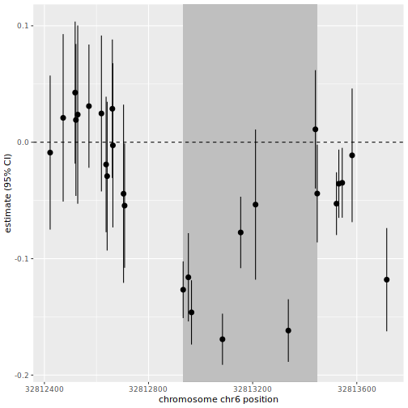

```r
best6 <- dmrs6[which.min(dmrs6$p.value),]
dmrff.plot(
    best6$chr, best6$start, best6$end,
    meta$ewas$estimate, meta$ewas$se, meta$ewas$chr, meta$ewas$pos)
```

We can use the same function to show the summary statistics for these sites from one of the original studies.

```r
acc <- "GSE79056"
sites <- dmrff.sites(dmrs6, stats[[acc]]$chr, stats[[acc]]$pos)
sites <- cbind(sites[,c("region","chr","pos")],
               stats[[acc]][sites$site,c("estimate","se","p.value")])
kable(sites,row.names=F)
```

| region | chr | pos | estimate | se | p.value |
| --- | --- | --- | --- | --- | --- |
| 1 | chr6 | 1635611 | 0.0053363 | 0.0006958 | 0.0000000 |
| 1 | chr6 | 1635640 | 0.0063335 | 0.0008181 | 0.0000000 |
| 1 | chr6 | 1635808 | 0.0073781 | 0.0007358 | 0.0000000 |
| 1 | chr6 | 1635818 | 0.0064351 | 0.0008352 | 0.0000000 |
| 1 | chr6 | 1635847 | 0.0083883 | 0.0007770 | 0.0000000 |
| 2 | chr6 | 15504844 | -0.0113105 | 0.0009718 | 0.0000000 |
| 2 | chr6 | 15504872 | -0.0100702 | 0.0009470 | 0.0000000 |
| 2 | chr6 | 15504923 | -0.0109958 | 0.0009858 | 0.0000000 |
| 2 | chr6 | 15505094 | -0.0184816 | 0.0016960 | 0.0000000 |
| 2 | chr6 | 15505345 | -0.0023223 | 0.0005873 | 0.0003840 |
| 2 | chr6 | 15505452 | -0.0017037 | 0.0004356 | 0.0004337 |
| 2 | chr6 | 15505460 | -0.0038243 | 0.0006648 | 0.0000020 |
| 2 | chr6 | 15505949 | -0.0049969 | 0.0009589 | 0.0000099 |
| 2 | chr6 | 15506085 | -0.0111326 | 0.0014722 | 0.0000000 |
| 3 | chr6 | 25652383 | 0.0029570 | 0.0004757 | 0.0000005 |
| 3 | chr6 | 25652390 | 0.0020246 | 0.0005783 | 0.0013540 |
| 3 | chr6 | 25652395 | 0.0011633 | 0.0005708 | 0.0496633 |
| 3 | chr6 | 25652405 | 0.0014082 | 0.0005784 | 0.0204916 |
| 3 | chr6 | 25652407 | 0.0005231 | 0.0004102 | 0.2111513 |
| 3 | chr6 | 25652531 | 0.0008247 | 0.0003650 | 0.0305841 |
| 3 | chr6 | 25652602 | 0.0010391 | 0.0003115 | 0.0021187 |
| 4 | chr6 | 28543262 | 0.0007349 | 0.0006114 | 0.2379327 |
| 4 | chr6 | 28543508 | 0.0010910 | 0.0006956 | 0.1266460 |
| 4 | chr6 | 28543514 | 0.0021095 | 0.0005610 | 0.0006616 |
| 4 | chr6 | 28543667 | 0.0083357 | 0.0014310 | 0.0000016 |
| 4 | chr6 | 28543670 | 0.0083497 | 0.0013315 | 0.0000004 |
| 5 | chr6 | 29520752 | 0.0051044 | 0.0016067 | 0.0032272 |
| 5 | chr6 | 29520774 | 0.0120810 | 0.0019128 | 0.0000004 |
| 5 | chr6 | 29520965 | 0.0038275 | 0.0009041 | 0.0001729 |
| 5 | chr6 | 29521013 | 0.0045393 | 0.0008581 | 0.0000086 |

[output cut: 515 more lines]

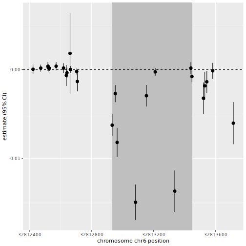

```r
best6 <- dmrs6[which.min(dmrs6$p.value),]
dmrff.plot(
    best6$chr, best6$start, best6$end,
    stats[[acc]]$estimate, stats[[acc]]$se, stats[[acc]]$chr, stats[[acc]]$pos)
```

Going back to full set of DMRs, we can ask which regions are novel, i.e. contain no CpG sites identified by Bohlin et al.

```r
## consider only autosomal regions
dmrs <- dmrs[which(dmrs$chr %in% paste0("chr", 1:22)),]
## collect CpG sites in the regions
sites <- dmrff.sites(dmrs, meta$ewas$chr, meta$ewas$pos)
sites <- cbind(sites, meta$ewas[sites$site,c("cpg","estimate","se","p.value")])
## identify sites with associations according to Bohlin et al.
sites$bohlin <- sites$cpg %in% rownames(bohlin)
## novel regions do not contain any of the Bohlin sites
dmrs$novel <- !(1:nrow(dmrs) %in% sites$region[sites$bohlin])
```

Of 1713 DMRs identified, 29.54% are novel.

They appear on the following chromosomes:

```r
freq.novel <- table(dmrs$chr[dmrs$novel])
freq <- table(dmrs$chr)
prop <- 100*freq.novel/freq
prop <- as.data.frame(prop)
colnames(prop) <- c("chr","pct")
prop$novel <- freq.novel
prop$total <- freq
prop <- prop[order(prop$pct),]
kable(prop,row.names=F,digits=2)
```

| chr | pct | novel | total |
| --- | --- | --- | --- |
| chr22 | 8.70 | 4 | 46 |
| chr19 | 22.89 | 19 | 83 |
| chr9 | 23.08 | 6 | 26 |
| chr14 | 25.00 | 14 | 56 |
| chr10 | 26.14 | 23 | 88 |
| chr11 | 26.47 | 36 | 136 |
| chr7 | 26.97 | 24 | 89 |
| chr18 | 27.27 | 3 | 11 |
| chr17 | 27.40 | 40 | 146 |
| chr21 | 28.57 | 4 | 14 |
| chr12 | 28.75 | 23 | 80 |
| chr2 | 30.30 | 30 | 99 |
| chr13 | 30.43 | 14 | 46 |
| chr6 | 30.46 | 60 | 197 |
| chr16 | 32.97 | 30 | 91 |
| chr5 | 33.33 | 20 | 60 |
| chr1 | 33.70 | 62 | 184 |
| chr4 | 34.09 | 15 | 44 |
| chr8 | 34.43 | 21 | 61 |
| chr15 | 36.59 | 15 | 41 |
| chr3 | 37.18 | 29 | 78 |
| chr20 | 37.84 | 14 | 37 |